# Taiwan Tracking Attitudes Analysis - University Collected Data

Paul M. Garrett

21/6/2020

The coronavirus disease of 2019 (COVID-19) is a highly transmittable viral infection caused by severe acute respiratory syndrome coronavirus 2 (SARS-CoV-2). The disease originated in Wuhan, China and was declared a pandemic by the World Health Organization on March 11th, 2020 (World Health Organization, 2020). The virus is estimated to have a basic R$_0$ – the average number of infected individuals from a single case – of 3.28 (median R$_0$ = 2.79; Liu, Gayle, Wilder-Smith, & Rocklöv, 2020) and an estimated median incubation period of 5 days (Lauer, et al., 2020) after which many [possibly up to 80%, still looking into this] infected individuals may present as asymptomatic (Day, 2020). The nature of this virus has required governments to consider technological solutions to help contain its spread (Bonsall, Parker, & Fraser, 2020). Taiwan has in many ways been at the vanguard of these efforts.

Taiwan has employed a combination of social distancing, stay-at-home policies, travel bans, and mobile tracking technologies to stop the spread of COVID-19 (see Figure 1). Mobile tracking technologies have been used in several ways: GPS data has been used to enforce at-home quarantines and locations determined by mobile network towers have been used to notify individuals who may have been in contact with an infected individual. Recently, Apple and Google launched their Bluetooth application programming interface (API) - a software intermediary that uses Bluetooth technology to notify people if they have been collocated with individuals who voluntarily identify as having COVID-19 (Albergotti, 2020).

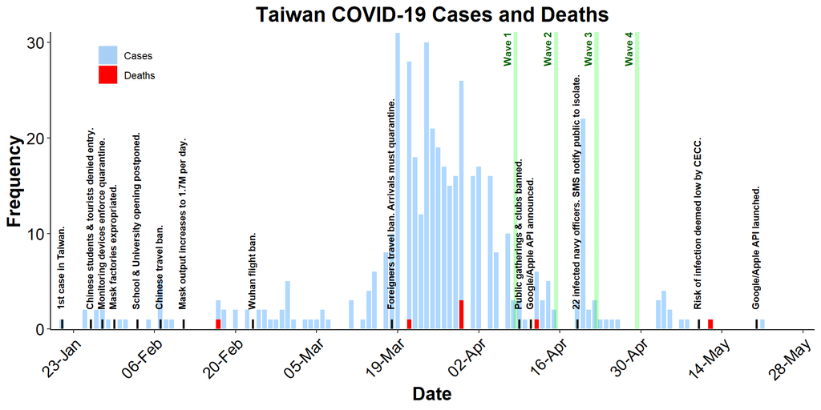

Figure 1. Key dates, cases, and deaths related to COVID-19 in Taiwan.

These technologies aim to track who you have been in contact with and when, affording users rapid notifications of possible infection and authorities rapid contact tracing. This is necessary as infected individuals may have as little as 24 hrs before becoming contagious (Liu, Gayle, Wilder-Smith, & Rocklöv, 2020). As Taiwan relaxes its restrictions, it faces a seemingly inevitable increase in cases: a ‘second wave’. During this period, easily accessible testing and rapid contact tracing will be imperative to stop the spread of the virus.

The effectiveness of these tracking technologies rely on the willingness of the population to support such measures, implying that government policy-making should be informed by the likelihood of public compliance. Gaining the social license – broad community acceptance beyond formal legal requirements – for collocation tracking requires the perceived public health benefits to outweigh concerns of personal privacy, security, and any potential risk of harm.

## The current study

We collected four waves of Taiwanese university students and members of the general public on April 8th, April 15th, April 22nd, and April 29th, and assessed their understanding of the COVID-19 pandemic, the perceived threat posed by COVID-19, and their attitudes towards three hypothetical mobile tracking scenarios. The aim of this study was to assess the social licence to operate these tracing methods within Taiwan, and to inform the Taiwanese Government’s policy decision making.

# Method

## Participants

Table 1. Participant selection procedure for data collection in waves 1-4.

| Wave | Initial Sample | Under 18 or over 29 | Failed Attention Check | Final Sample |
| --- | --- | --- | --- | --- |
| Wave 1 | 731 | 300 | 40 | 391 |
| Wave 2 | 249 | 15 | 33 | 201 |
| Wave 3 | 301 | 0 | 35 | 266 |
| Wave 4 | 170 | 1 | 22 | 147 |

## Design

Four samples of Taiwanese participants completed a 10 (waves 1 and 2) or 15 mintue (waves 3 and 4) online Qualtrics survey. Participants reported their demographics, perceptions of the COVID-19 pandemic, trust in the government, and attitudes towards a described method of mobile tracking. Participants also completed the Conner-Davidson Resilience Scale, a 25 item measure to assess resilience during the COVID-19 outbreak.

Participants viewed one of two (waves 1 and 2) or one of three (waves 3 and 4) hypothetical mobile tracking scenarios in a between-subjects design. Scenarios described mobile network tracking with enforcable fines for breaking lockdown laws, a voluntary and centralised government app, or a decentralised Bluetooth tracing API developed by Apple and Google. Due to the timeline of events (see Figure 1), this third scenario was only introduced in waves 3 and 4. Each scenario is described below:

### Scenario one - Voluntary government Bluetooth tracking

“The COVID-19 pandemic has rapidly become a worldwide threat. Containing the virus’ spread is essential to minimize the impact on the healthcare system, the economy, and save many lives. The Australian Government might consider using smartphone tracking data to identify and contact those who may have been exposed to people with COVID-19. This would help reduce community spread by identifying those most at risk and allowing health services to be appropriately targeted. **Only people that downloaded a government app and agreed to be tracked and contacted would be included in the project.** The more people that download and use this app the more effectively the Government would be able to contain the spread of COVID-19. **Data would be stored in an encrypted format on a secure server accessible only to the Australian Government. Data would only be used to contact those who might have been exposed to COVID-19.**”

### Scenario two - Mandatory government mobile network tracking

“The COVID-19 pandemic has rapidly become a worldwide threat. Containing the virus’ spread is essential to minimize the impact on the healthcare system, the economy, and save many lives. The Australian Government might consider using phone tracking data supplied by telecommunication companies to identify and contact those who may have been exposed to people with COVID-19. This would help reduce community spread by identifying those most at risk and allowing health services to be appropriately targeted. **All people using a mobile phone would be included in the project, with no possibility to opt-out.** Data would be stored in an encrypted format on a secure server accessible only **to the Australian Government who may use the data to locate people who were violating lockdown orders and enforce them with fines and arrests where necessary.** Data would also be used to inform the appropriate public health response and to contact those who might have been exposed to COVID-19, and individual quarantine orders could be made on the basis of this data.”

### Scenario three - Voluntary third-part Bluetooth tracking (wave 3 and 4 only)

“The COVID-19 pandemic has rapidly become a worldwide threat. Containing the virus’ spread is essential to minimize the impact on the healthcare system, the economy, and save many lives. **Apple and Google have proposed adding a contact tracing capability to existing smartphones to help inform people if they have been exposed to others with COVID-19.** This would help reduce community spread of COVID-19 by allowing people to voluntarily self-isolate. When two people are near each other, their phones would connect via Bluetooth. If a person is later identified as being infected, the people they have been in close proximity to are then notified **without the government knowing who they are. The use of this contact tracing capability would be completely voluntary. People who are notified would not be informed who had tested positive.**”

# Results

## Demographics

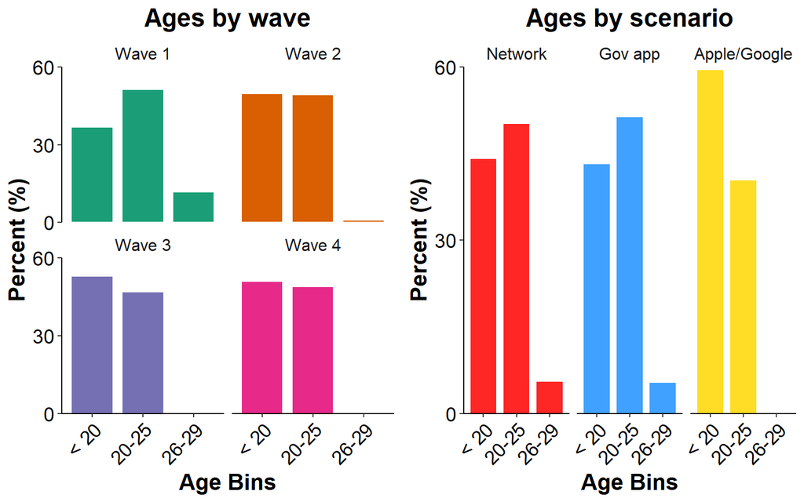

Figure 2. Ages sampled by wave and scenario.

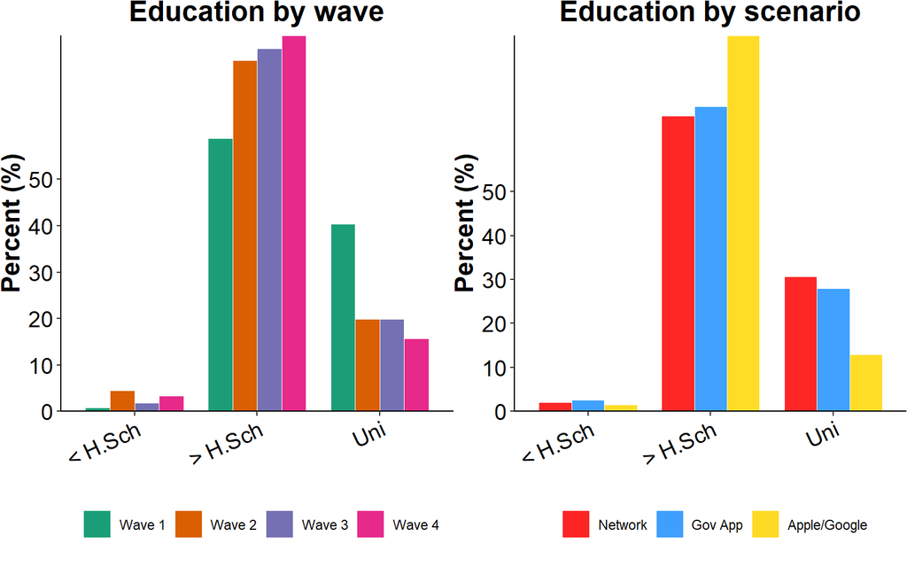

Figure 3. Education by wave and scenario.

| Level of education by wave: Percentages | Level of education by wave: Percentages | Level of education by wave: Percentages | Level of education by wave: Percentages Percent |
| --- | --- | --- | --- |
| W$WaveN |  |  |  |
| Wave 1 | W$education | < H.Sch | 0.8 |
|  |  | > H.Sch | 58.8 |
|  |  | Uni | 40.4 |
|  |  | #Total cases | 391 |
| Wave 2 | W$education | < H.Sch | 4.5 |
|  |  | > H.Sch | 75.6 |
|  |  | Uni | 19.9 |
|  |  | #Total cases | 201 |
| Wave 3 | W$education | < H.Sch | 1.9 |
|  |  | > H.Sch | 78.2 |
|  |  | Uni | 19.9 |
|  |  | #Total cases | 266 |
| Wave 4 | W$education | < H.Sch | 3.4 |
|  |  | > H.Sch | 81 |
|  |  | Uni | 15.6 |
|  |  | #Total cases | 147 |

## Impact of COVID-19

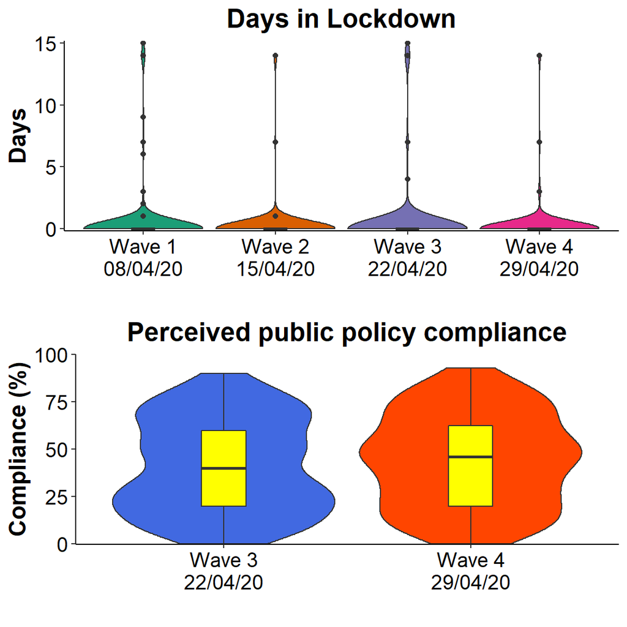

Figure 4. Days in lockdown and perceived policy compliance.

| Days in lockdown: Percentages | Days in lockdown: Percentages | Days in lockdown: Percentages | Days in lockdown: Percentages Percent |
| --- | --- | --- | --- |
| x$WaveN |  |  |  |
| Wave 3 | x$LockdownDays | 0 | 94.7 |
|  |  | 1 – 10 | 1.5 |
|  |  | 11 – 20 | 3.8 |
|  |  | #Total cases | 266 |
| Wave 4 | x$LockdownDays | 0 | 96.6 |
|  |  | 1 – 10 | 2 |
|  |  | 11 – 20 | 1.4 |
|  |  | #Total cases | 147 |

## Perceptions of COVID-19

The most common source of COVID-19 information came from news sources (63%), followed by social media (30%), and then TV (4%) and friends and family (2%; see Figure 5).

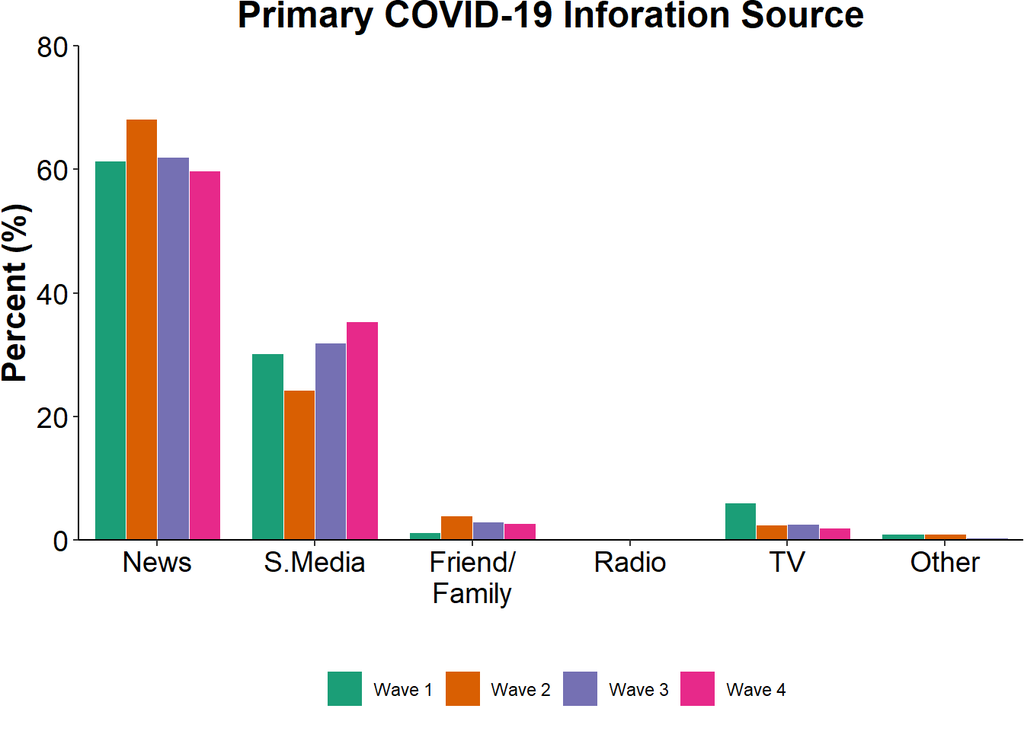

Figure 5. Self reported primary COVID-19 information sources.

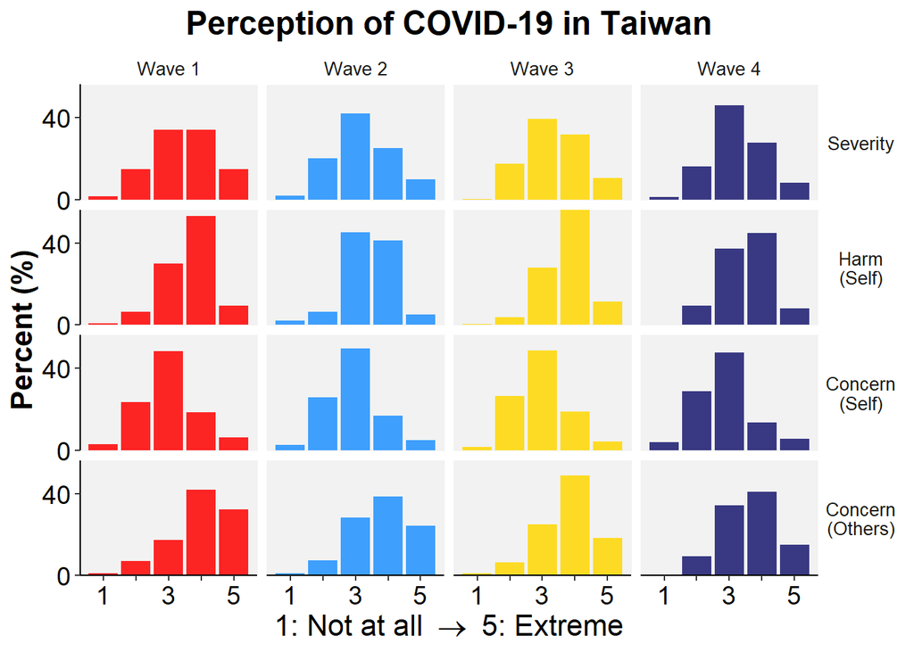

Figure 6. Perceptions of COVID-19 severity, risk of harm to one’s self, and concern for self and others.

We asked participants in waves 3 and 4 to report their estimates on the number of fatalities for a range of countries with moderate-to-high media coverage in Taiwan using sliding scale ranging from 0 - 100,000; results are reported in estimated deaths per 1000 (see Figure 7).

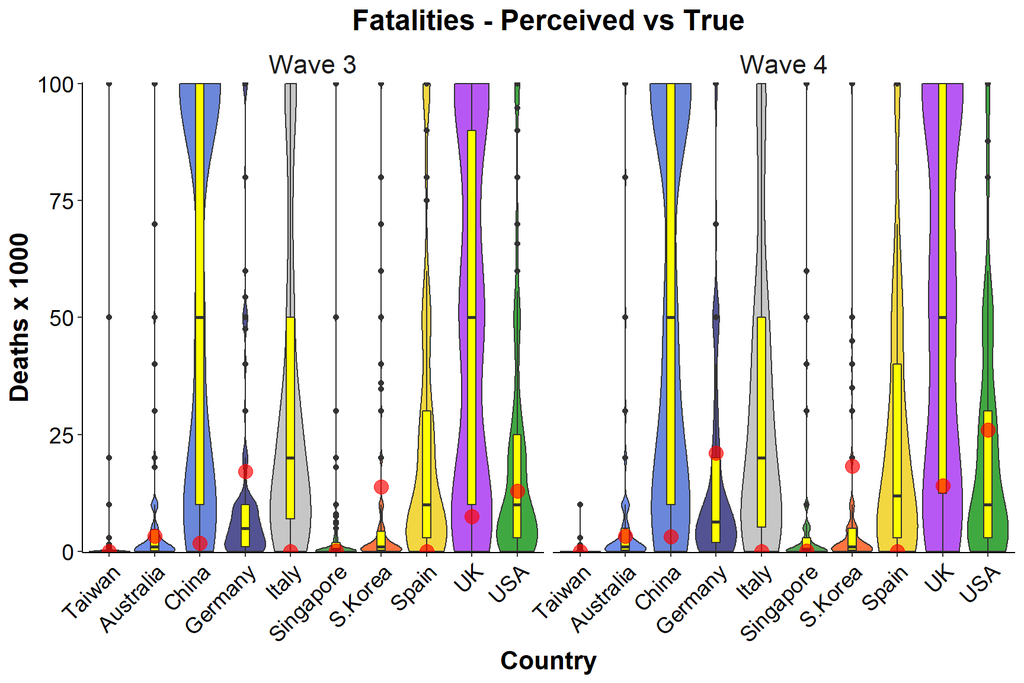

Figure 7. Perceived national fatalities by wave.

## Attitudes towards mobile tracking

Figure 8 characterizes participant’s confidence that in each scenario Government tracking would:

1. Reduce their likelihood of contracting COVID-19
2. Reduce spread of COVID-19 in the community.
3. Allow them to resume their normal lives more rapidly

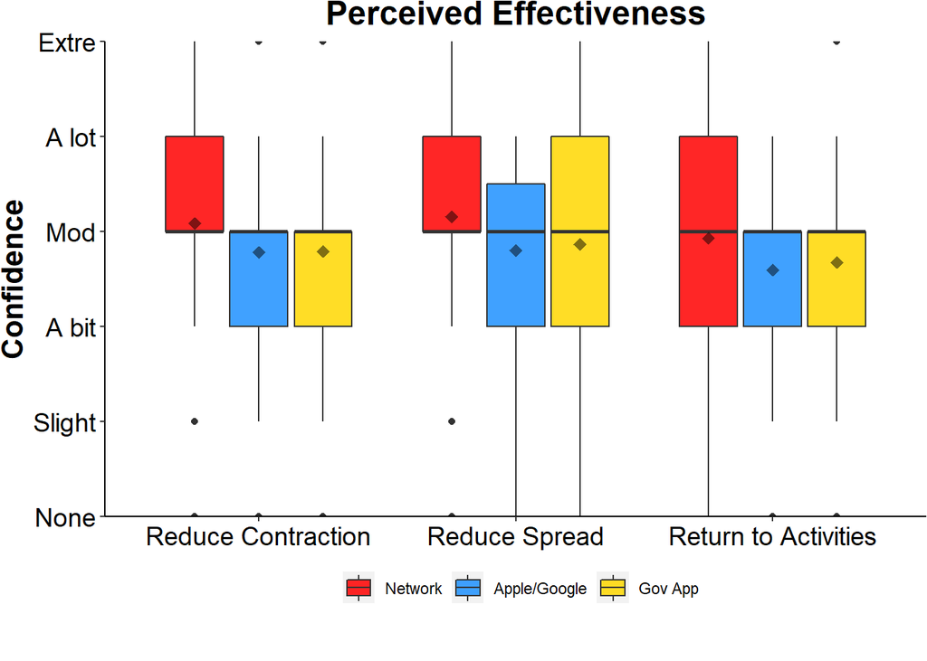

Figure 8. Perceived effectivenesss of each tracking method. Back diamonds denote the mean of the ordinal values for comparison across groups. Box plots denote the interquatile range and black lines denote the median value.

Figure 9 shows responses to the following items (abridged from the survey):

1. How confident are you that someone like you could use the proposed method?
2. How easy is it for people to decline participation in the proposed project?
3. To what extent is the Government or Google/Apple only collecting the data necessary?
4. How sensitive is the data being collected in the proposed project?
5. How serious is the risk of harm that could arise from the proposed project?
6. How much do you trust the Government or Google/Apple to use the tracking data only to deal with the COVID-19 pandemic?
7. How much do you trust the Government or Google/Apple will be able to ensure the privacy of each individual?
8. How secure is the data that would be collected for the proposed project?
9. To what extent do people have ongoing control of their data?

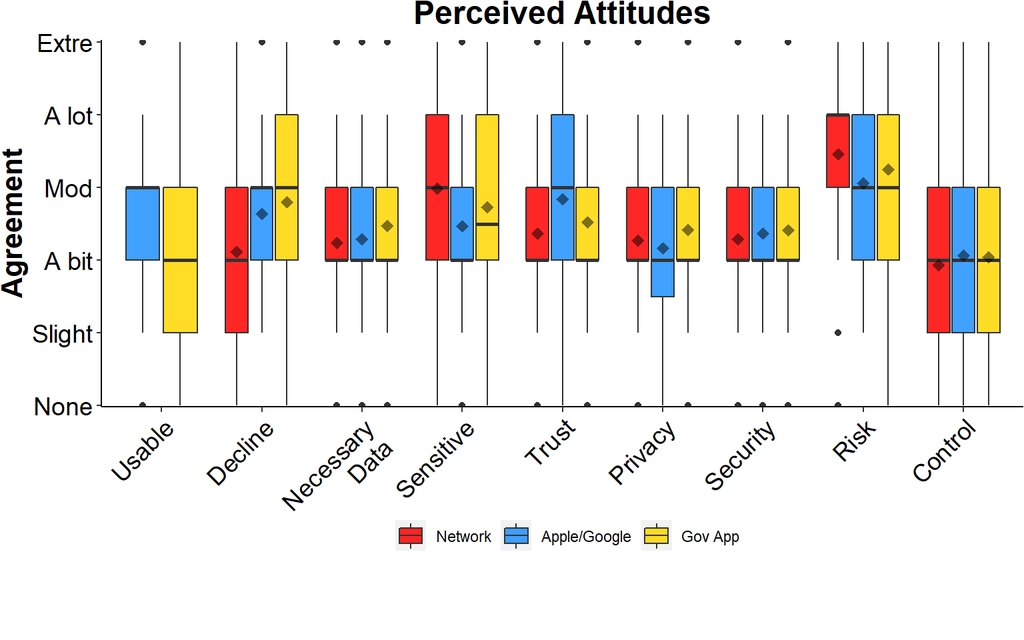

Figure 9. Perceived attitudes towards tracking scenarios. Back diamonds denote the mean of the ordinal values for comparison across groups. Box plots denote the interquatile range and black lines denote the median value.

## Acceptability of mobile tracking

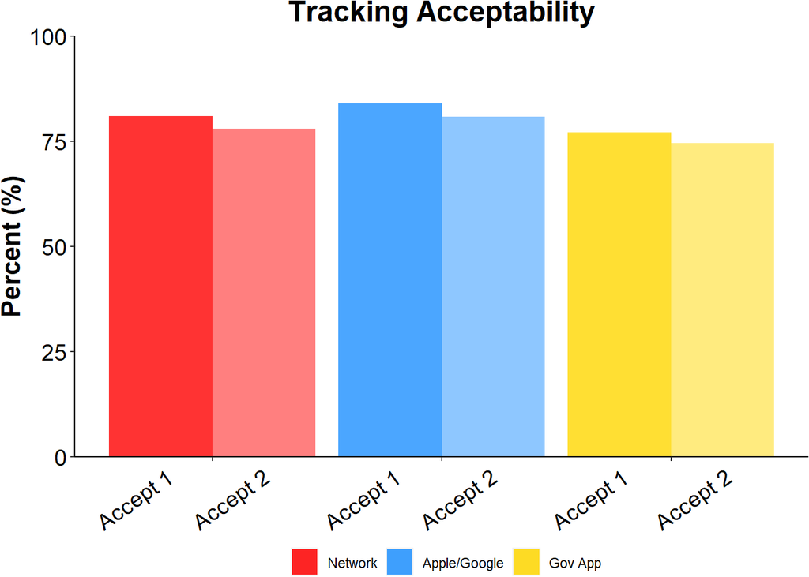

Figure 10. Acceptability of mobile tracking pre and post answering questions about the tracking methods.

Table 2. Acceptability of mobile tracking methods pre and post questions.

| Acceptability (%) | Network | Apple/Google | Gov App |
| --- | --- | --- | --- |
| Accept 1 | 80.94 | 83.97 | 77.1 |
| Accept 2 | 78.03 | 80.92 | 74.53 |

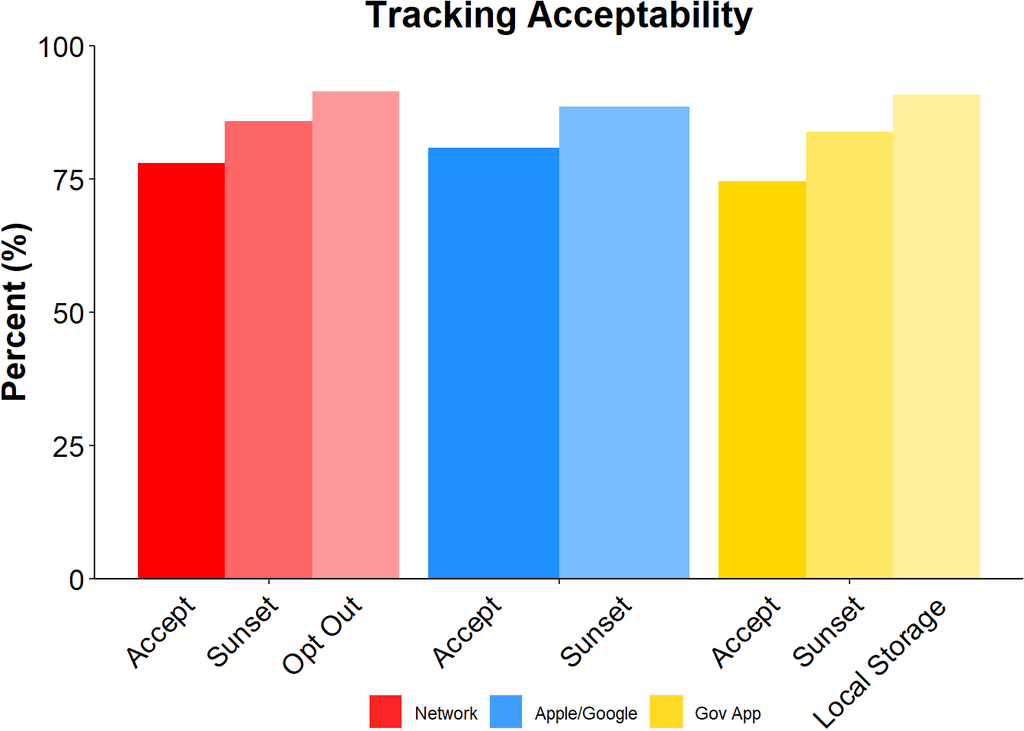

Figure 11. Tracking acceptability for each scenario with and without conditional options.

# References

The world health organization (2020). WHO announces COVID-19 outbreak a pandemic. Retrieved from http://www.euro.who.int/en/health-topics/health-emergencies/coronavirus-covid-19/news/news/2020/3/who-announces-covid-19-outbreak-a-pandemic.

Day, M. (2020). [Covid-19: four fifths of cases are asymptomatic, China figures indicate.](https://www.bmj.com/content/369/bmj.m1375.short) British Medical Journal.

Lauer, S. A., Grantz, K. H., Bi, Q., Jones, F. K., Zheng, Q., Meredith, H. R., … & Lessler, J. (2020). [The incubation period of coronavirus disease 2019 (COVID-19) from publicly reported confirmed cases: estimation and application.](https://www.acpjournals.org/doi/10.7326/M20-0504) Annals of internal medicine. doi 10.7326/M20-0504

Liu, Y., Gayle, A. A., Wilder-Smith, A., & Rocklöv, J. (2020). The reproductive number of COVID-19 is higher compared to SARS coronavirus. Journal of travel medicine.

Bonsall, D., Parker, M., & Fraser, C. (2020). Sustainable containment of COVID-19 using smartphones in China: Scientific and ethical underpinnings for implementation of similar approaches in other settings.

Govtech Singapore (2020). [Tracetogether - behind the scenes look at its development process.](https://www.tech.gov.sg/media/technews/tracetogether-behind-the-scenes-look-at-its-development-process) Retrieved from https://www.tech.gov.sg/media/technews/tracetogether-behind-the-scenes-look-at-its-development-process.

The Economist (2020). Countries are using apps and data networks to keep tabs on the pandemic Retrieved from https://www.economist.com/briefing/2020/03/26/countries-are-using-apps-and-data-networks-to-keep-tabs-on-the-pandemic?fsrc=newsletter&utm_campaign=the-economist-today&utm_medium=newsletter&utm_source=salesforce-marketing-cloud&utm_term=2020-05-07&utm_content=article-link-1

The Australian Government department of health (2020). [The COVIDSafe app.](https://www.health.gov.au/resources/apps-and-tools/covidsafe-app)Retrieved from https://www.health.gov.au/resources/apps-and-tools/covidsafe-app

J. Taylor, (2020). [NSW is unable to use Covidsafe app’s data for contact tracing](https://www.theguardian.com/australia-news/2020/may/19/nsw-and-victoria-are-unable-to-use-covidsafe-apps-data-for-contact-tracing). The Guardian. Retrived from https://www.theguardian.com/australia-news/2020/may/19/nsw-and-victoria-are-unable-to-use-covidsafe-apps-data-for-contact-tracing

J. Taylor (2020). [Coronavirus apps: how Australia’s Covidsafe compares to other countries’ contact tracing technology.](https://www.theguardian.com/australia-news/2020/may/03/coronavirus-apps-how-australias-covidsafe-compares-to-other-countries-contact-tracing-technology). The Guardian. Retrieved from https://www.theguardian.com/australia-news/2020/may/03/coronavirus-apps-how-australias-covidsafe-compares-to-other-countries-contact-tracing-technology

R, Albergotti (2020). [Apple and Google launch coronavirus exposure software.](https://www.washingtonpost.com/technology/2020/05/20/apple-google-api-launch/) Retrieved from (https://www.washingtonpost.com/technology/2020/05/20/apple-google-api-launch/